# Praca domowa 2

Konrad Niesyt

## Dane

Dane wykorzystane w Pracy domowej 2 dotyczą wyników egzaminów z 3 umiejętności: czytania, pisania i operacji matematycznych. Dodatkowo dostępne są podstawowe informacje o studentach i ich rodzicach. Opis wszystkich kolumn znajduje się również w pliku `README.md`.

| Zmienna | Opis |
| --- | --- |
| **gender** | płeć |
| **race.ethnicity** | pochodzenie etniczne |
| **parental.level.of.education** | wykształcenie rodziców |
| **lunch** | jaki obiad jedli uczniowie w dniu egzaminu |
| **test.preparation.course** | czy uczeń odbył kurs przygotowujący |
| **math.score** | wynik egzaminu z matematyki |
| **reading.score** | wynik egzaminu z czytania |
| **writing.score** | wynik egzaminu z pisania |

## Zadanie 1

Jak wyglądają rozkłady wyników uczniów z trzech przedmiotów (matematyka, czytanie, pisanie)?

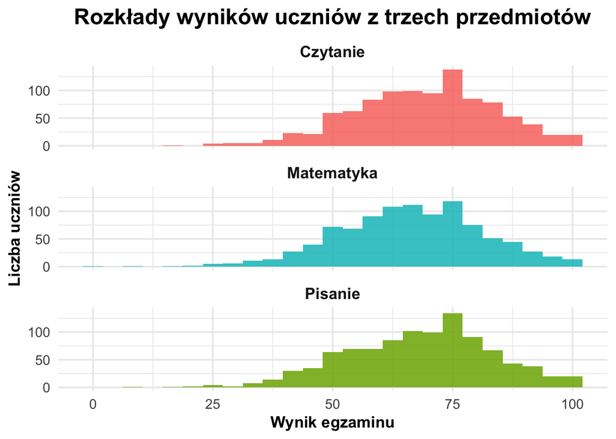

```r
df_long <- df %>%
  pivot_longer(cols = c(math.score, reading.score, writing.score),
               names_to = "przedmiot",
               values_to = "wynik") %>%
    mutate(przedmiot = recode(przedmiot,
                          "math.score" = "Matematyka",
                          "reading.score" = "Czytanie",
                          "writing.score" = "Pisanie"))

df_long %>%
  ggplot(aes(x = wynik, fill = przedmiot)) +
  geom_histogram(bins = 25, alpha = 0.85) +
  facet_wrap(~przedmiot, ncol = 1) +
  scale_fill_manual(values = c("Czytanie" = "#F8766D",
                               "Matematyka" = "#00BFC4",
                               "Pisanie" = "#7CAE00")) +
  labs(
    title = "Rozkłady wyników uczniów z trzech przedmiotów",
    x = "Wynik egzaminu",
    y = "Liczba uczniów",
    fill = "Przedmiot"
  ) +
  theme_minimal(base_size = 14) +
  theme(
    plot.title = element_text(face = "bold", size = 18, hjust = 0.5),
    legend.position = "None",
    legend.title = element_text(face = "bold"),
    axis.title = element_text(size = 13, face = "bold"),
    strip.text = element_text(size = 13, face = "bold"),
  )
```

**Komentarz: Zdecydowana większość uczniów osiąga wyniki powyżej 50% punktów, najczęściej osiągany wynik oscyluje w okolicach 75% punktów możliwych do zdobycia. Rozkłady wyników z czytania, pisania i matematyki są do siebie bardzo zbliżone.**

## Zadanie 2

Czy istnieje zauważalna różnica w wynikach między uczniami i uczennicami?

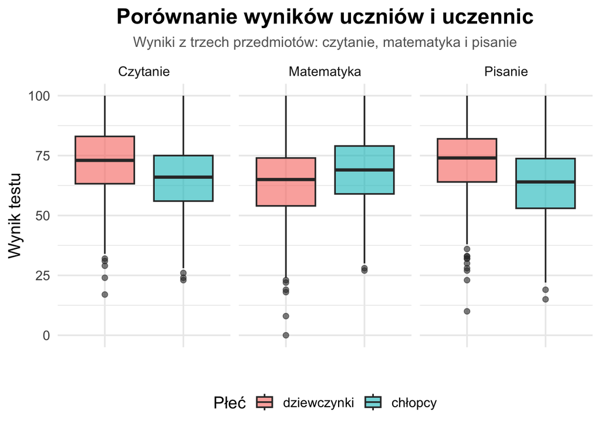

```r
ggplot(df_long, aes(x = gender, y = wynik, fill = gender)) +
  geom_boxplot(alpha = 0.6) +
  facet_wrap(~przedmiot, ncol = 3) +
    scale_fill_manual(
    values = c("female" = "#F8766D", "male" = "#00BFC4"),
    labels = c("female" = "dziewczynki", "male" = "chłopcy")
  ) +
  theme_minimal() +
  labs(title = "Porównanie wyników uczniów i uczennic",
       subtitle = "Wyniki z trzech przedmiotów: czytanie, matematyka i pisanie",
       x = "",
       y = "Wynik testu",
       fill = "Płeć") +
  theme_minimal(base_size = 14) +
  theme(
    plot.title = element_text(face = "bold", size = 18, hjust = 0.5),
    plot.subtitle = element_text(size = 12, hjust = 0.5, color = "gray40"),
    legend.position = "bottom",
    axis.text.x = element_blank(),
    axis.ticks.x = element_blank()
  )
```

**Komentarz: Uczennice osiągają lepsze wyniki z czytania i pisania, natomiast uczniowie z matematyki.**

## Zadanie 3

Czy uczniowie, którzy ukończyli kurs przygotowawczy, osiągają lepsze wyniki niż pozostali?

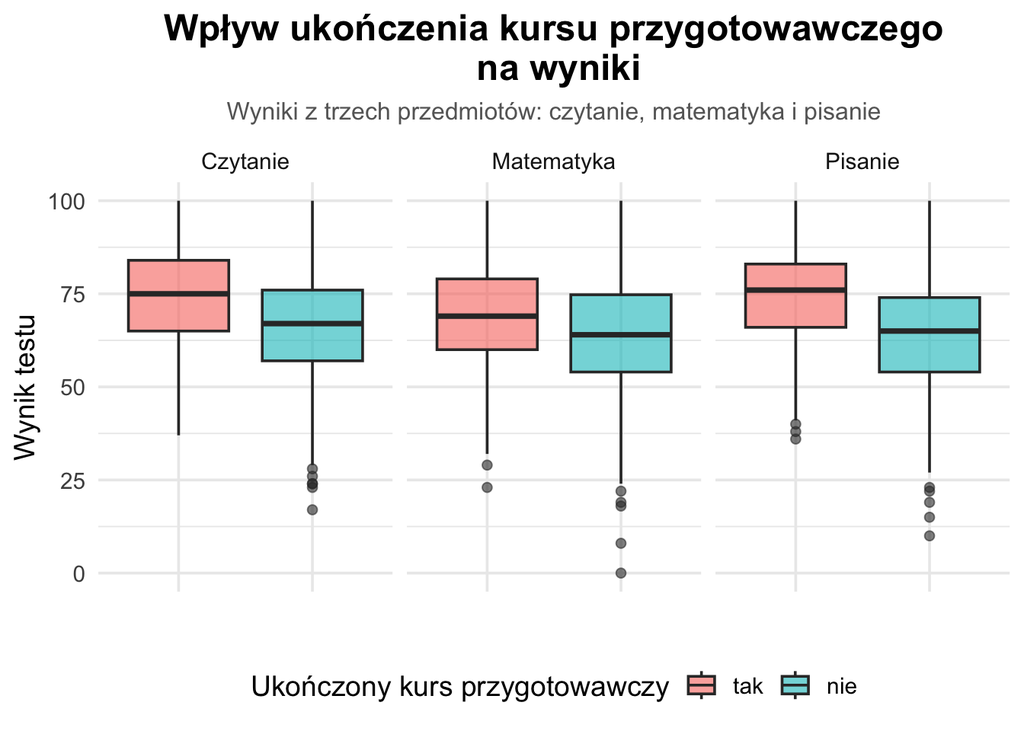

```r
ggplot(df_long, aes(x = test.preparation.course, y = wynik, fill = test.preparation.course)) +
  geom_boxplot(alpha = 0.6) +
  facet_wrap(~przedmiot, ncol = 3) +
    scale_fill_manual(
    values = c("completed" = "#F8766D", "none" = "#00BFC4"),
    labels = c("completed" = "tak", "none" = "nie")
  ) +
  theme_minimal() +
  labs(title = "Wpływ ukończenia kursu przygotowawczego\n na wyniki",
       subtitle = "Wyniki z trzech przedmiotów: czytanie, matematyka i pisanie",
       x = "",
       y = "Wynik testu",
       fill = "Ukończony kurs przygotowawczy") +
  theme_minimal(base_size = 14) +
  theme(
    plot.title = element_text(face = "bold", size = 18, hjust = 0.5),
    plot.subtitle = element_text(size = 12, hjust = 0.5, color = "gray40"),
    legend.position = "bottom",
    axis.text.x = element_blank(),
    axis.ticks.x = element_blank()
  )
```

**Komentarz: Tak. Uczniowie, którzy ukończyli kurs przygotowawczy osiągają lepsze wyniki niż pozostali na wszystkich trzech egzaminach.**

## Zadanie 4

Jaki jest związek między poziomem wykształcenia rodziców a średnimi wynikami uczniów?

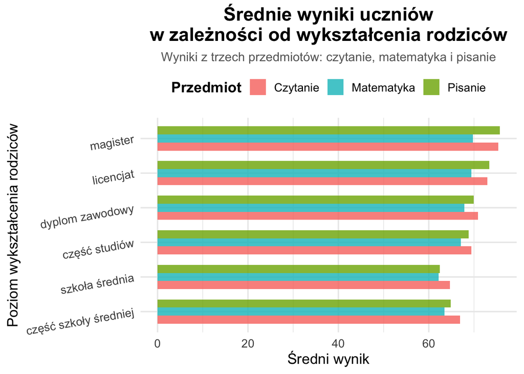

```r
df_long$parental.level.of.education <- factor(
  df_long$parental.level.of.education,
  levels = c(
    "some high school",
    "high school",
    "some college",
    "associate's degree",
    "bachelor's degree",
    "master's degree"
  )
)

df_long$parental.level.of.education <- recode(
  df_long$parental.level.of.education,
  "some high school" = "część szkoły średniej",
  "high school" = "szkoła średnia",
  "some college" = "część studiów",
  "associate's degree" = "dyplom zawodowy",
  "bachelor's degree" = "licencjat",
  "master's degree" = "magister"
)

df_long %>%
  group_by(parental.level.of.education, przedmiot) %>%
  summarise(mean_score = mean(wynik, na.rm = TRUE)) %>%
  ggplot(aes(x = parental.level.of.education,
             y = mean_score,
             fill = przedmiot)) +
  geom_col(position = "dodge", alpha = 0.8, width = 0.7) +
  coord_flip() +
  scale_fill_manual(values = c("Czytanie" = "#F8766D",
                               "Matematyka" = "#00BFC4",
                               "Pisanie" = "#7CAE00")) +
  labs(
    title = "Średnie wyniki uczniów\nw zależności od wykształcenia rodziców",
    subtitle = "Wyniki z trzech przedmiotów: czytanie, matematyka i pisanie",
    x = "Poziom wykształcenia rodziców",
    y = "Średni wynik",
    fill = "Przedmiot"
  ) +
  theme_minimal(base_size = 14) +
  theme(
    plot.title = element_text(face = "bold", size = 18, hjust = 0.5),
    plot.subtitle = element_text(size = 12, hjust = 0.5, color = "gray40"),
    legend.position = "top",
    legend.title = element_text(face = "bold"),
    axis.text.y = element_text(angle = 10)
  )
```

## Zadanie 5

Czy płeć i wykształcenie rodzica wpływa na wynik z matematyki?

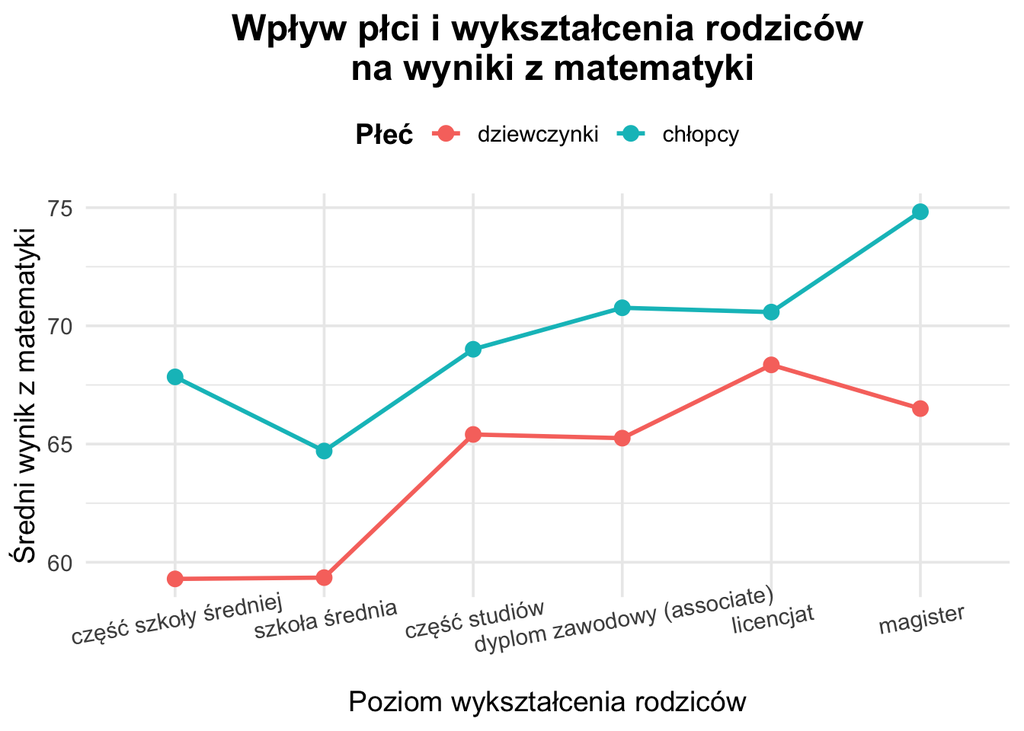

```r
df_summary <- df %>%
  group_by(gender, parental.level.of.education) %>%
  summarise(
    sredni_wynik = mean(math.score, na.rm = TRUE),
    sd = sd(math.score, na.rm = TRUE),
    n = n(),
    .groups = "drop"
  )

df_summary$parental.level.of.education <- factor(
  df_summary$parental.level.of.education,
  levels = c(
    "some high school",
    "high school",
    "some college",
    "associate's degree",
    "bachelor's degree",
    "master's degree"
  )
)

df_summary$parental.level.of.education <- recode(
  df_summary$parental.level.of.education,
  "some high school" = "część szkoły średniej",
  "high school" = "szkoła średnia",
  "some college" = "część studiów",
  "associate's degree" = "dyplom zawodowy (associate)",
  "bachelor's degree" = "licencjat",
  "master's degree" = "magister"
)

ggplot(df_summary, aes(x = parental.level.of.education,
                       y = sredni_wynik,
                       color = gender,
                       group = gender)) +
  geom_point(size = 3) +
  geom_line(linewidth = 1) +
  scale_color_manual(values = c("female" = "#F8766D", "male" = "#00BFC4"),
                     labels = c("female" = "dziewczynki", "male" = "chłopcy")) +
  theme_minimal(base_size = 14) +
  labs(
    title = "Wpływ płci i wykształcenia rodziców\n na wyniki z matematyki",
    x = "Poziom wykształcenia rodziców",
    y = "Średni wynik z matematyki",
    color = "Płeć"
  ) +
  theme(
    plot.title = element_text(face = "bold", size = 18, hjust = 0.5),
    plot.subtitle = element_text(size = 12, hjust = 0.5, color = "gray40"),
    legend.position = "top",
    legend.title = element_text(face = "bold"),
    axis.text.x = element_text(angle = 10)
  )
```

## Zadanie 6

Czy istnieje zależność między wynikami z matematyki a wynikami z czytania lub pisania?

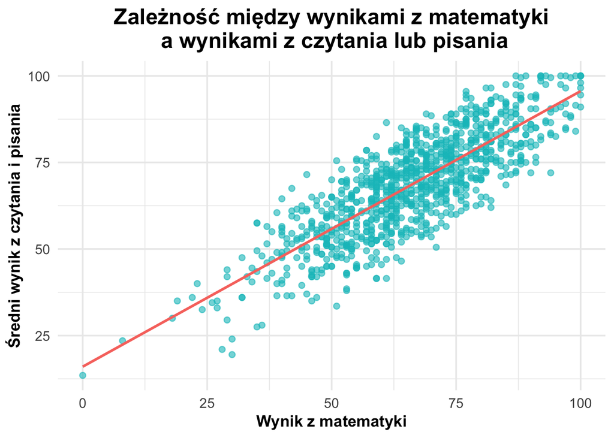

```r
ggplot(df, aes(x = math.score,
               y = (reading.score + writing.score) / 2)) +
  geom_point(alpha = 0.6, color = "#00BFC4") +
  geom_smooth(method = "lm", se = FALSE, color = "#F8766D", linewidth = 1) +
  theme_minimal(base_size = 14) +
  labs(
    title = "Zależność między wynikami z matematyki\n a wynikami z czytania lub pisania",
    x = "Wynik z matematyki",
    y = "Średni wynik z czytania i pisania"
  ) +
  theme(
    plot.title = element_text(face = "bold", size = 18, hjust = 0.5),
    axis.title = element_text(size = 13, face = "bold"),
  )
```

**Komentarz: Tak, istnieje liniowa zależność pomiędzy wynikami z matematyki a wynikami z czytania lub pisania.**